# Training, Sleep, and Recovery Dynamics in Recreational Runners: A Longitudinal Wearable Analytics Study

## 2 Data & Methods

### 2.1 Participants and Data Collection

Fourteen recreational runners (nine male, five female; participants P001–P015 excluding P007) were recruited in Nairobi, Kenya. Each wore a Garmin device continuously throughout the study period (January 2022 – February 2026). The device recorded resting heart rate, sleep stage proportions (light, deep, REM, awake), Body Battery charge and drain cycles, GPS-derived session speed and distance, and estimated VO₂max. Table 1 summarises the cohort.

Table 1: Cohort characteristics by participant. VO₂max values are drawn from the LOCF-imputed variable. Three participants (P006, P013, P015) lack sleep staging data and are excluded from sleep architecture analyses. P008 is excluded from Body Battery analyses (0% coverage).

| Participant | Sex | Age | VO₂max range (ml/kg/min) | Observation days | Analysis cohort |
| --- | --- | --- | --- | --- | --- |
| P001 | Male | 38 | 45–57 | 1290 | Full |
| P002 | Male | 37 | 43–54 | 445 | Full |
| P003 | Male | 34 | 49–62 | 352 | Full |
| P004 | Male | 35 | 48–52 | 127 | Full |
| P005 | Male | 37 | 43–54 | 529 | Full |
| P006 | Male | 45 | 37–47 | 1483 | Limited |
| P008 | Male | 35 | 41–51 | 1402 | Full |
| P009 | Male | 38 | 46–71 | 1386 | Full |
| P010 | Female | 41 | 33–45 | 810 | Full |
| P011 | Female | 42 | 23–33 | 728 | Full |
| P012 | Female | 38 | 38–47 | 1232 | Full |
| P013 | Male | 43 | 44–52 | 1427 | Limited |
| P014 | Female | 37 | 39–48 | 1399 | Full |
| P015 | Female | 39 | 31–39 | 150 | Limited |

**Note**

**Cohorts.** The *full* cohort (n = 11) includes all participants with valid sleep staging data and is used for analyses involving Sleep Quality % or REM/deep sleep proportions. The *all* cohort (n = 14) is used for analyses relying solely on sleep duration, sleep efficiency, or session load. All mixed-effects models are fitted on the all-participant dataset unless otherwise noted.

### 2.2 Variable Definitions

Table 2: Key variable definitions used throughout the report.

| Variable | Definition | Unit | Notes |
| --- | --- | --- | --- |
| Recovery Score | −(daily RHR − 7-day rolling mean RHR); positive = well-recovered | bpm deviation | Requires ≥7 days of valid RHR |
| Session Load | ActivitiesAvgHr × session duration (min) | AU | Proxy for internal training load |
| Sleep Quality (SQ%) | (Deep sleep proportion + REM proportion) × 100; capped at 75% | % | Absent for P006, P013, P015 |
| Sleep Efficiency (SE%) | (Time asleep / Time in bed) × 100 | % | Correlated with sleep depth |
| Sleep Fragmentation (SF%) | Awake proportion × 100 | % | Higher = more fragmented sleep |
| Sleep Duration (TSD) | Total sleep duration | hours | Nights < 3 h or > 12 h excluded |
| Relative Intensity (RI%) | (Average session HR / Maximum HR) × 100 | % | Higher = more aerobically demanding |
| Running Economy (RE) | Average speed (km/h) / Average HR (bpm) | (km/h)/bpm | Lower = more economical at given effort |
| BB delta | Charged(t+1) − Drained(t), clamped to ±20; aligns with Recovery Score(t+1) | AU | P008 excluded (0% Body Battery coverage) |
| Training Monotony | Weekly mean load / Weekly SD of load (Foster, 1998) | dimensionless | Monotony > 2 signals overtraining risk |

### 2.3 Data Quality and Missingness

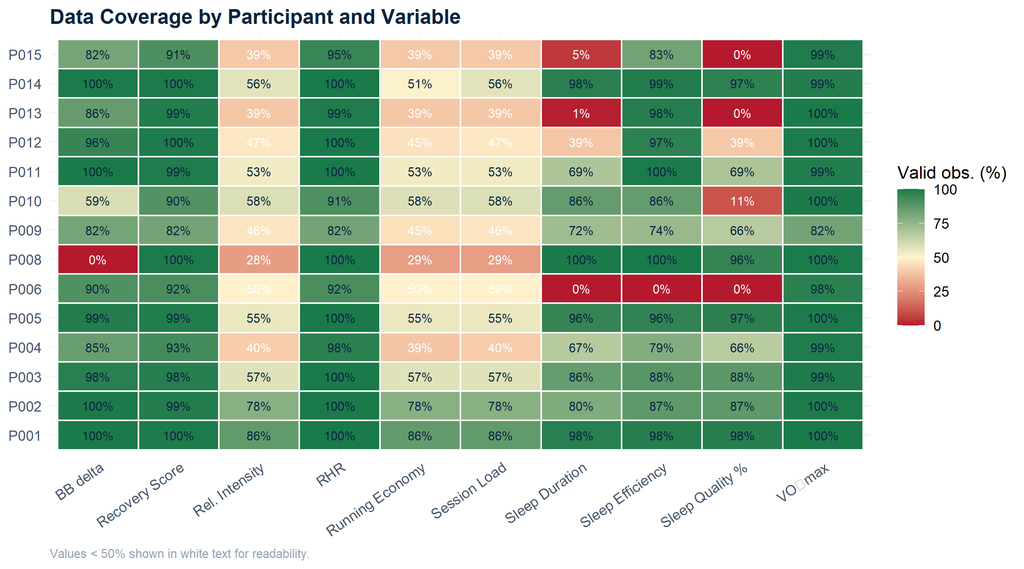

Figure 1: **Data coverage heatmap.** Each cell shows how much of a given variable was successfully recorded for each participant, as a percentage. Green means near-complete data, red means little or no data, with the exact percentage printed inside each cell.

**Warning**

Two analysis cohorts are maintained throughout: the *full* cohort (11 participants, all sleep variables available) and the *all* cohort (14 participants, restricted to variables available across all devices).

### 2.4 Statistical Approach

All bivariate associations are characterised using the Spearman rank correlation coefficient (ρ), which makes no distributional assumptions and is robust to the right-skewed, heteroscedastic distributions typical of wearable data. Lagged analyses pair observations on day *t* with outcomes on days *t+1*, *t+2*, and *t+3*, with all lead/lag operations computed within participant groups to prevent cross-participant data leakage. Primary inferential models are linear mixed-effects models (LME) fitted with `lme4::lmer()` using restricted maximum likelihood (REML), with a random intercept for each participant to account for baseline differences in RHR and the repeated-measures structure of the data. The significance threshold is α = 0.05; exact p-values are reported throughout. Effect sizes for Spearman ρ are interpreted following Cohen’s benchmarks: small ≥ 0.10, medium ≥ 0.30, large ≥ 0.50.

**Note**

**Power caveat.** With n = 14 participants, between-person comparisons are substantially underpowered. Mixed-effects models yield adequate power for within-person effects by leveraging the full longitudinal depth (~12,760 observations) but should not be used to draw strong conclusions about participant-level differences.

## 3 Training Behaviour

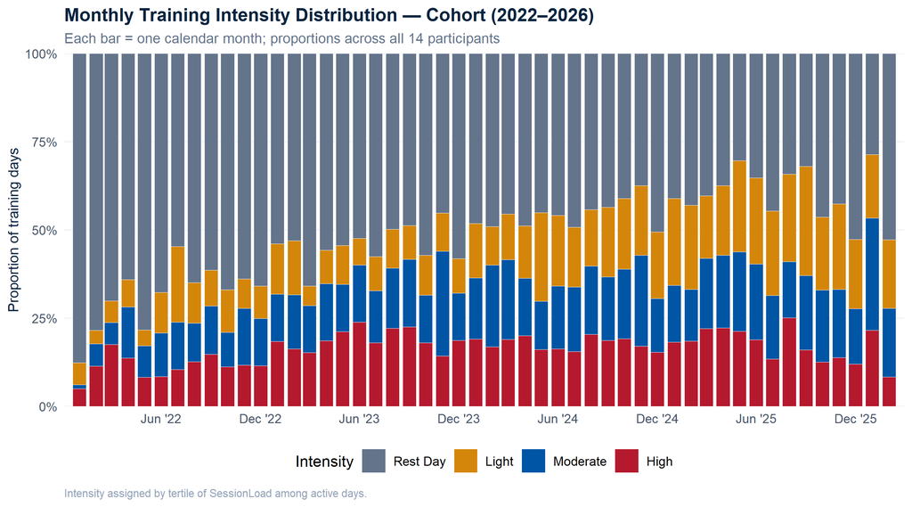

Figure 2: **Monthly training intensity distribution.** Each bar represents one calendar month. The bar is divided into coloured bands showing what proportion of that month’s training days were Rest (grey), Light (amber), Moderate (blue), or High intensity (red). All bands in a bar add up to 100%.

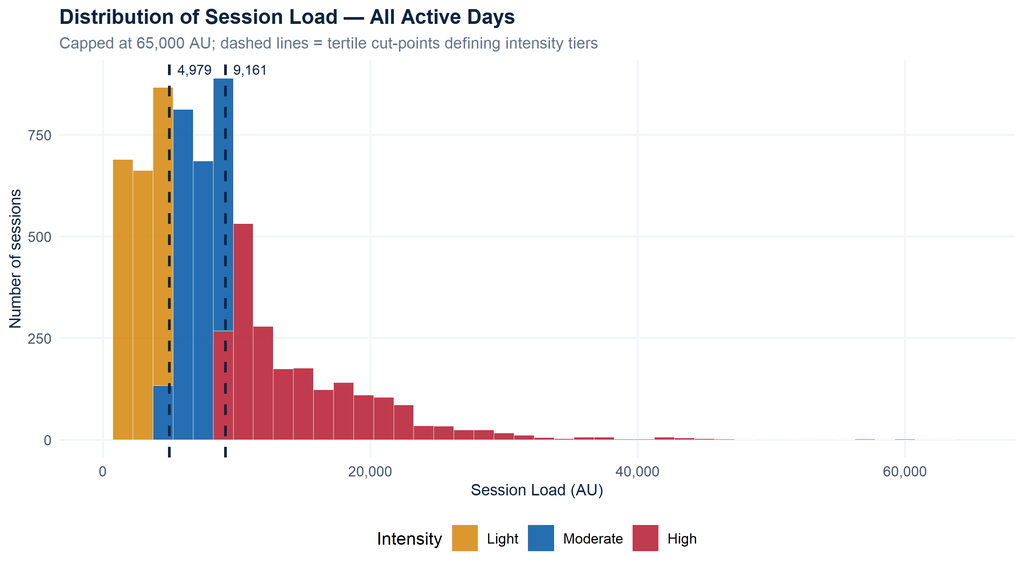

Figure 3: **Session Load histogram — all active training days.** Each bar counts how many sessions fell within that load range, coloured by intensity tier. The two dashed vertical lines show where the boundaries between Light, Moderate, and High sessions sit, with the load value labelled at each boundary.

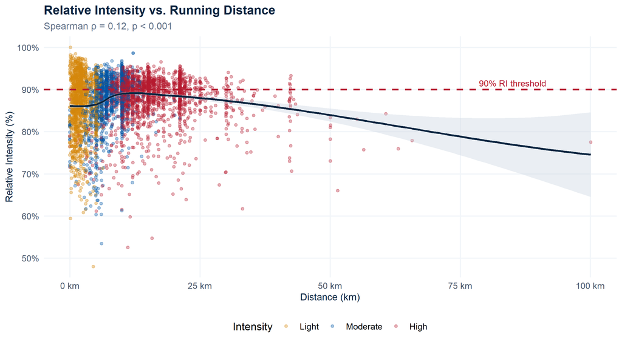

Figure 4: **Relative Intensity vs. running distance.** Each dot is one training session, coloured by intensity tier, showing how hard the athlete ran (as a percentage of their maximum heart rate) against how far they ran. The curved line is a smoothed trend through all sessions; the dashed horizontal line marks the 90% intensity threshold. The correlation strength is shown in the subtitle.

The load histogram (Figure 3) reveals a strongly right-skewed distribution: the vast majority of active-day sessions fall below 20,000 AU, while a sparse tail of high-effort days extends toward the 65,000 AU cap. The tertile cut-points (dashed lines) sit well within the dense region of the distribution, confirming that the tier boundaries capture genuinely distinct physiological stimuli rather than arbitrary quantile splits. The right tail — driven by races and back-to-back training days — is a feature of naturalistic training data absent from controlled laboratory protocols.

Overall, the training behaviour of this cohort is broadly consistent with guidelines for recreational runners: high volume at low intensity punctuated by infrequent high-intensity sessions. The naturalistic data capture day-to-day variability in training adherence that controlled studies obscure, providing an ecologically valid foundation for the subsequent analyses of sleep and recovery.